# Session 1 Get Started

Steph de Silva

20/10/2018

Welcome to learning R! We’re going to start out with the basics. This file will guide you through your introduction to R.

# How does R *work*?

R is a high level programming language. It’s built on lower level programming languages like C++.

It’s *high level* which means there’s a lot of functionality built in to make life easier on the programmer.

Most people use R in an *integrated development environment (IDE)*. The most popular of these is RStudio. The advantage of an IDE is that there is alot of built in tools and functionality to make life easier as a programmer.

You’ll note we talk alot about *ease*. That’s because I, personally, am lazy.

# Introducing the IDE

Since you will most likely be using R in the IDE, let’s introduce it to you to start with.

There are four main windows in the RStudio IDE, though there are others.

[figure not shown]

Four main windows

Let’s start by trying out the console. Try typing `2 + 3` in the console window, hit enter.

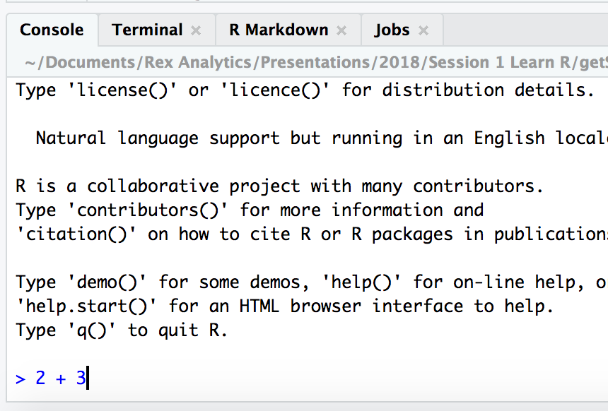

Using the console

What happens? Good. You’ve just discovered that R is your new desktop calculator.

Let’s create a new R script, where we can record and write large amounts of code.

[figure not shown]

New R script

Let’s put some code in it now.

Try putting in `x <- 2 + 3`, then saving your file.

Highlight the code and press `command + enter` and check the environment window.

[figure not shown]

First code

Congratulations, you’ve run your first script!

# Where do things live in R?

Finding where things *are* can be a real challenge when learning a new programming language and IDE.

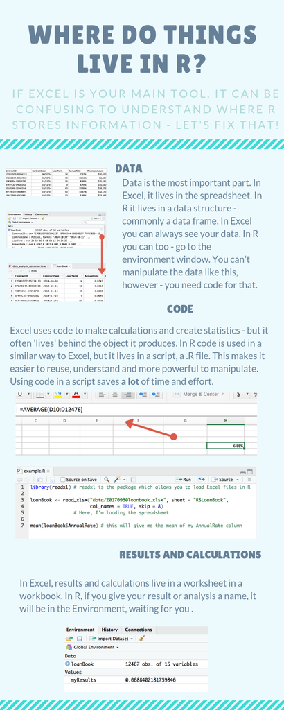

Where does it live?

# R lives and breathes *packages*

The real power of R is a world wide community of developers, nerds and enthusiasts who are constantly writing new packages - chunks of code that you can reuse for you own purpose.

There are many places these packages can be retrieved from, but one of those places is Github. The package that generates this document is in a github repository and you can download it.

Copy the following code into the console: this downloads the package. You only need to do this once.

```r
install.packages("devtools")
devtools::install_github("stephdesilva/getStarted")
```

Now to load the package into the environment, type this:

```r
library(getStarted)
```

You’ve now got this package and the code that generates this document on your computer.

# Time to get some data

Getting data into R the first time can be tricky, so this package has a simple function to get us some data to start with.

Open a new script and type, highlight and press `command/control + enter`.

```r
db <- getWitchData()
```

Check out the environment window - do you see db? Click on it.

This is a data frame. A data frame is one of many types of data structures in R.

There’s *homogenous data structures*:

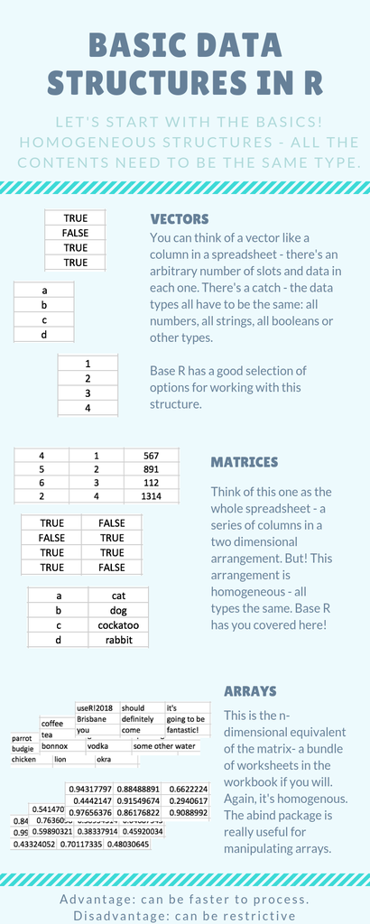

Data structures in R

There are also *heterogeneous data structures*, and a dataframe like `db` is one of these:

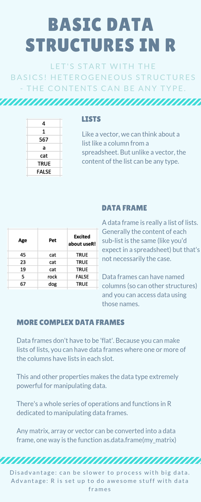

Heterogeneous data structures in R

The data frame `db` has 12 variables. Variables are very similar to variables in SAS.

# Starting a data analysis

One of the main things you’ll want to use R for is data analysis. Let’s use `db` to do a simple data analysis.

Let’s start by seeing what’s inside `db`.

The top rows:

```r
head(db)
```

```
##   year decade century tried deaths city gadm.adm2 gadm.adm1 lon lat
## 1   NA   1520    1500     1      1 <NA>      <NA>      <NA>  NA  NA
## 2   NA   1530    1500     1      1 <NA>      <NA>      <NA>  NA  NA
## 3   NA   1540    1500     5      5 <NA>      <NA>      <NA>  NA  NA
## 4   NA   1580    1500     7      5 <NA>      <NA>      <NA>  NA  NA
## 5   NA   1590    1500    11      0 <NA>      <NA>      <NA>  NA  NA
## 6   NA   1600    1600     6      1 <NA>      <NA>      <NA>  NA  NA
##   record.source country
## 1  Madar (1990) Estonia
## 2  Madar (1990) Estonia
## 3  Madar (1990) Estonia
## 4  Madar (1990) Estonia
## 5  Madar (1990) Estonia
## 6  Madar (1990) Estonia
```

The bottom rows:

```r
tail(db)
```

```
##       year decade century tried deaths city gadm.adm2 gadm.adm1 lon lat
## 10935 1730   1730    1700     3      0 <NA>      <NA>   Sachsen  NA  NA
## 10936 1740   1740    1700     2      0 <NA>      <NA>   Sachsen  NA  NA
## 10937 1750   1750    1700     1      0 <NA>      <NA>   Sachsen  NA  NA
## 10938 1760   1760    1700     4      0 <NA>      <NA>   Sachsen  NA  NA
## 10939 1770   1770    1700     6      0 <NA>      <NA>   Sachsen  NA  NA
## 10940 1790   1790    1700     1      0 <NA>      <NA>   Sachsen  NA  NA
##       record.source country
## 10935  Wilde (2003) Germany
## 10936  Wilde (2003) Germany
## 10937  Wilde (2003) Germany
## 10938  Wilde (2003) Germany
## 10939  Wilde (2003) Germany
## 10940  Wilde (2003) Germany
```

Summarise the data quickly:

```r
summary(db)
```

```
##       year          decade        century         tried
##  Min.   :1300   Min.   :1300   Min.   :1300   Min.   :  1.000
##  1st Qu.:1597   1st Qu.:1590   1st Qu.:1500   1st Qu.:  1.000
##  Median :1630   Median :1620   Median :1600   Median :  1.000
##  Mean   :1621   Mean   :1615   Mean   :1569   Mean   :  3.953
##  3rd Qu.:1660   3rd Qu.:1650   3rd Qu.:1600   3rd Qu.:  1.000
##  Max.   :1850   Max.   :1850   Max.   :1800   Max.   :500.000
##  NA's   :931
##      deaths              city              gadm.adm2
##  Min.   :  0.000   Geneva  : 320   Mittelfranken:1303
##  1st Qu.:  0.000   Budingen: 264   East Lothian : 516
##  Median :  0.000   Bruges  : 121   Darmstadt    : 493
##  Mean   :  2.296   Munich  :  80   Stuttgart    : 450
##  3rd Qu.:  1.000   Augsburg:  75   Fife         : 363
##  Max.   :500.000   (Other) :4867   (Other)      :6768
##  NA's   :3826      NA's    :5213   NA's         :1047
##              gadm.adm1         lon              lat
##  Scotland         :3129   Min.   :-3.534   Min.   :41.38
##  Bayern           :1388   1st Qu.: 6.154   1st Qu.:47.73
##  Baden-Wurttemberg:1153   Median : 8.765   Median :48.53
##  England          : 619   Mean   : 8.291   Mean   :48.55
##  Hessen           : 519   3rd Qu.:10.489   3rd Qu.:49.76
##  (Other)          :3973   Max.   :19.820   Max.   :54.77
##  NA's             : 159   NA's   :5803     NA's   :5803
##                record.source            country
##  Goodare et al. (2003):3128   United Kingdom:3750
##  Behringer (1987)     :1330   Germany       :3417
##  Midelfort (1972)     :1031   Switzerland   :1272
##  Monter (1976)        : 837   France        : 807
##  Kieckhefer (1976)    : 529   Belgium       : 671
##  Niess (1982)         : 512   Sweden        : 353
##  (Other)              :3573   (Other)       : 670
```

There’s a really useful package called `skimr` which helps you see your data very quickly and efficiently. To get it, we install it first, then load it into the library.

[output not shown]

```r
install.packages("skimr") # you only need to do this the first time you load a package
```

Now to load it into the environment:

```r
library(skimr) # you need to do this every time.
```

Then we use the function we want to skim the data:

```r
skim(db) # the function we want
```

```
## Skim summary statistics
##  n obs: 10940
##  n variables: 12
##
## ── Variable type:factor ──────────────────────────────────────────────────────────────────────────────────
##       variable missing complete     n n_unique
##           city    5213     5727 10940      906
##        country       0    10940 10940       19
##      gadm.adm1     159    10781 10940      113
##      gadm.adm2    1047     9893 10940      365
##  record.source       0    10940 10940       38
##                                 top_counts ordered
##     NA: 5213, Gen: 320, Bud: 264, Bru: 121   FALSE
##  Uni: 3750, Ger: 3417, Swi: 1272, Fra: 807   FALSE
##  Sco: 3129, Bay: 1388, Bad: 1153, Eng: 619   FALSE
##    Mit: 1303, NA: 1047, Eas: 516, Dar: 493   FALSE
##  Goo: 3128, Beh: 1330, Mid: 1031, Mon: 837   FALSE
##
## ── Variable type:integer ─────────────────────────────────────────────────────────────────────────────────
##  variable missing complete     n    mean    sd   p0  p25  p50  p75 p100
##   century       0    10940 10940 1569.2  72.61 1300 1500 1600 1600 1800
##    deaths    3826     7114 10940    2.3  16.3     0    0    0    1  500
##     tried       0    10940 10940    3.95 19.26    1    1    1    1  500
##      year     931    10009 10940 1621.06 66.25 1300 1597 1630 1660 1850
##      hist
##  ▁▁▁▂▇▁▁▁
##  ▇▁▁▁▁▁▁▁
##  ▇▁▁▁▁▁▁▁
##  ▁▁▁▂▇▇▁▁
##
## ── Variable type:numeric ─────────────────────────────────────────────────────────────────────────────────
##  variable missing complete     n    mean    sd      p0     p25     p50
##    decade       0    10940 10940 1614.87 66.68 1300    1590    1620
##       lat    5803     5137 10940   48.55  1.65   41.39   47.73   48.53
##       lon    5803     5137 10940    8.29  2.89   -3.53    6.15    8.77
##      p75    p100     hist
##  1650    1850    ▁▁▁▂▇▅▁▁
##    49.76   54.78 ▁▁▂▅▇▅▁▁
##    10.49   19.82 ▁▁▂▆▇▃▁▁
```

What do we now know about our data?